# Final Project

Author

Affiliation

Luke Sheppard

University of Pennsylvania

Published

May 12, 2025

#1. Introduction

In light of current events and the broad restructuring of significant US foreign aid apparatus, I investigate this aid legacy on whether US foreign aid projects fuel corruption. Corruption as a measure covers both local-level or petty and elite corruption. Although the bad actors differ strongly by level of control, the result remains the same, the exploitation of resources and institutions by government officials. Previously, corruption within the developing world was understood as a political reality necessary to grease the wheels of development. This paper staunchly rejects that claim and agrees with modern sentiments that corruption in its many forms overwhelmingly inhibits economic and political development. Thus, the possible perpetuation or encouragement of corruption resulting from aid detracts from possible gains made. This research question addresses the continuing debate within the literature on the effectiveness of foreign aid, especially on recipient institutional capacity. Although estimates of aid lost to corruption are widely overstated there remains the threat that aid funding is mismanaged and misappropriated by bad state actors creating ineffective programs and further entrenching regressive outcomes (Kenny (2024)). However, by design aid flows to countries with lower institutional capacities and high levels of corruption, thus some level of mismanagement of foreign aid is inevitable. I estimate whether US foreign aid has historically exacerbated existing corruption and whether there exists a causal relationship between US foreign aid deliverance and recipient corruption.

The US has historically been the largest donor of foreign aid in the world. For eight decades, the US has been a massive donor primarily due to its significant economic capacity and historical commitment to international assistance (Ingram (2024)). American aid has played an important and diverse role globally in the development of allied states and global outcomes. Additionally, it seeks to advance US interests by contributing to national security through regional and global stability, reflecting US cultural values, and advancing economic interests through market development. As such, current events call into question the vast and powerful legacy of US foreign aid.

Existing research debates the possibility of regressive effects from foreign aid. Aid disbursements correspond with investments in tax safe havens from recipient countries, misappropriation by elites, suggesting an aid leakage rate around 7.5% (Anderson (2022)). In concentrated transfers, significant leakage is observed by local officials varying strongly by community bargaining power (Reinikka and Svensson (2004)). Foreign aid leakage from local and elite corruption has distributional consequences and may exacerbate regressive outcomes as corruption affects aid distribution along existing power and income lines. Despite aid goals, implementation difficulties associated with corruption and low capacity in poorer, more remote locations result in disproportionate distribution of aid to richer communities (Briggs (2017)). Thus donors also self select into aid projects along existing inequalities in response to patterns of local bargaining, corruption, and aid mismanagement. Aid is institutionally vulnerable to corruption at every step despite significant protections and restrictions to dispel bad actors.

Historically, corruption concerns have inspired other aid pathways to limit state seizure and misappropriation. Although states have information and implementation advantages, due to leakage and fungibility concerns donors often forego budget support and recipient control by circumventing local institutions through project aid delivered by non-governmental organizations (NGOs) (Reinikka and Svensson (2004)). Due to structural limitations, aid often bypasses state institutions by relying on NGOs contributing to government distrust by interfering with state capacities and citizens’ ability to hold politicians accountable. NGO service delivery weakens the “Fiscal Link,” the link between state performance and citizen welfare through taxation and public service delivery, and undermines accountability as politicians get credit for aid disbursements manipulating political attitudes (Cruz and Schneider (2017)). This undeserved credit claiming varies both on voter information and local oversight and capacity, decreasing accountability pathways in communities with existing low responsiveness and entrenching bad state actors (Baldwin and Winters (2023)). Governance aid projects, designed to build state capacity and public trust cognizant of the aid dependence debate, may have negligible effects due to aid’s impact on political incentives, communication networks, and other community mechanisms to support local trust and legitimacy (Evans (2021)). The transient effect of aid also creates misalignment as projects often fail to be translated into systematic or institutional change due to political or economic windfalls, scale or conceptual complications in increasing project access to larger populations, and implementation difficulties in shifting from NGO to government provision (Bold et al. (2018)). Foreign aid and its implementation concerns due to leakage may further cycles of foreign dependence and local incapacity.

Besides recipient pathways, foreign aid is tied to political and economic dynamics in donor countries, much like the current events motivating this paper, which depend on motivations outside of improving recipient outcomes. Bilateral donors have strategic reasons in aid selection which may rebound in restrictions on NGOs or foreign actors such as laws targeting democracy/governance promotion from countries wary of foreign interference and Western imperialism. As the biggest donor, the US has concentrated aid on legacy and soft power concerns attempting to win hearts and minds and spread american economic and cultural values globally. Recipient citizens are informed of where aid comes from and often its conditionality. While aid improves trust in foreign institutions, these soft power battles and their implementation through state and non-state actors have lasting effects on institutional capacity (Dietrich and Winters (2023)). Foreign aid is controlled by outside donors based on perceived recipient corruption and geopolitical importance or donor foreign policy objectives and ignorance. In summary, the existing literature recognizes the precarious relationship between foreign aid and quality of government due to leakage, implementation difficulties, and disruptions to state institutions which may perpetuate debilitating corruption already within these institutions.

Previous studies have thoroughly examined the effect of foreign aid on corruption in a variety of settings. Aid has been reliably shown to influence institutional capacity and exacerbate corruption to varying degrees within specific projects and countries. Internal and external reviews of World Bank projects, US field interventions, NGO programs, and more have found different results moderated by their specific contexts but all agree that corruption remains a threat to aid delivery. Similarly, mega studies analyzing total ODA disbursements compared to national corruption ratings have found negligible results. One example found no significant reduction impact on corruption but failed to differentiate by aid type or recipient (Okada and Samreth (2012)). My research design attempts to add to this extensive literature by blending macro indicators with the contextual pathways previously enumerated by sector. I specify a donor, the US, as a case study where strategic interests may impact aid commitments by sector and identity the causal pathways by which different aid sectors affect institutions and public perceptions in development to provide a sector-based approach moving beyond generalist aid research. My approach relies on aid commitments due to the difficulty in accessing accurately reported disbursements.

#2. Theory and Hypotheses

Does foreign aid delivery exacerbate recipient corruption? Previous research has highlighted how the delivery of aid is susceptible to seizure by bad state actors at both the elite and local level, weakens the fiscal link and accountability measures between governments and their citizens, and minimizes domestic trust due to foreign intervention and implementation volatility. To effectively estimate the validity of these causal pathways, I examine aid projects aggregated by sector: humanitarian, economic, social infrastructure, and specifically governance. Types of aid vary in target and implementation, affecting how vulnerable they are to domestic and foreign factors affecting corruption through citizens perceptions of their governments and institutional capacity.

Although humanitarian aid would be expected to target areas specifically in crisis and strategic objectives, economic and social infrastructure aid would be expected to target countries where poverty prevention and long-term political, social, and economic development seem feasible i.e. countries with sufficient state capacity and stability to implement projects partnering with recipients. NGOs contribute primarily to health, education, agriculture, and other social infrastructure costs more than government institutions as donors prefer NGOs over local capabilities whenever possible. Donors also recognize instability and local incapacity harming these sectors and the effective rate of return for service delivery. However, NGOs are unable to contribute to industries with hardcore infrastructure costs such as transportation, energy, water/sanitation, business/trade development, etc. Thus, the impact on citizen perception of government service delivery should center around high cost infrastructure rather than direct delivery service which is often appropriated by NGOs.

Although foreign aid is increasingly effective and resistance to leakage, the foreign delivery of services affects recipient capabilities. While multilateral development aid prioritizes delivery where preferences overlap, bilateral development is dependent on variable domestic factors which may further disrupt effective aid. As a result, I predict bilateral development aid has complex effects varying by sector on recipient quality of governance. Specifically, I predict that aid which delivers services reliably susceptible to leakage and corruption and for these reasons generally through non-state actors such as healthcare, social infrastructure, and education will decrease perceptions of corruption due to credit claiming. These sectors, which low capacity states ineffectively provide, are vital for alleviating human suffering and improving citizen outcomes. Thus, donors will prioritize these industries for political and logistical ease. As donors seek to more effectively provide services and inform citizenry of their benevolence, I expect domestic governance capabilities will resultedly decrease while inversely citizens’ perception of domestic governments will be distracted by temporary service deployment. I hypothesize that as social infrastructure aid increases, measures of corruption decrease.

Conversely, governance aid, aid specifically designed to promote state capacity, may have limited effects. Governance projects compete with foreign aid service delivery and thus even successful projects increasing state capacity will have less impact on citizen perception than these far reaching projects including health and education impacting daily lives. Additionally, citizens perception of governance will be more largely controlled by trust in local and national institutions and their credit claiming of foreign aid service delivery. Thus increasing US aid funding for sectors delivering services will cause increased perceptions of corruption. In comparison, increasing or decreasing US aid funding for governance projects will cause negligible changes in perceptions of corruption. These predictions reflect earlier cited research and my own theoretical reasoning that citizens will respond more effectively to high implementation projects involving service delivery. Inversely, governance projects targeting unstable areas will suffer from existing corruption, target areas with traditional implementation problems, and have minimal impact on citizenry. Thus, I hypothesize that as governance aid increases, measures of corruption will be unchanged. I expect governance aid to be ineffective and thus minimal correlation.

Finally, humanitarian aid involves highly realizable services in emergency areas based heavily on donor strategic interests. Prior research shows that trust in foreign governments, the soft power US foreign aid targets, increases after humanitarian aid arrives while domestic trust changes minimally. These types of aid highlight state incapacity in highly public examples minimizing the ability for local credit claiming. Thus, I hypothesize that as humanitarian aid increases, measures of corruption will increase.

#3. Research Design

##3a. Data

Foreign aid data is difficult to capture due to the disparate sources of aid. Tracking disbursements and project implementation relies on significant and unheard of oversight of both donors and recipients. I rely on aid commitments and a reliable tracker of aid projects. For the independent variable, foreign aid commitments by sector, I will use AidData’s Research Release on Development Projects Summary. “AidData’s Core Research Release 3.1 is a snapshot of AidData’s entire project-level database which includes commitment information for over 1.5 million development finance activities funded between 1947 and 2013 covering 96 donors” (Tierney and Hicks. (2011)). This data captures development projects by donor, recipient, commitment, and sector. The unit of analysis is projects and I filter by donor for US projects and aggregate by sector such that my unit of analysis will be aid sectors by country and year. I have aggregated sectors into the 4 categories mentioned in my hypotheses: social infrastructure, economic, humanitarian, and governance. These sectors are aggregated with significant assumptions and ignore other avenues of aid delivery including multisector aid.

Ultimately, local or elite corruption is incredibly difficult to measure accurately. Inherently obscured and protected, any measure of corruption relies on significant assumptions. Effective measures to observe aid leakage and state corruption have been designed as aggregate measures. For the dependent variable I will use corruption indexes from a variety of sources including household surveys (Afrobarometer surveys, Gallup World Poll, and Global Competitiveness Report survey, etc.), Commercial business information providers, Non-governmental organizations, and Public sector organizations aggregated by World Governance Indicators from the World Bank Group. This measure aggregates a variety of original primary data that cover multiple countries and report respondents’ perceptions of relevant dimensions of governance. WGI includes 6 aggregated measures of governance for over 200 economies over the period 1996–2023 including Voice and Accountability, Political Stability and Absence of Violence/Terrorism, Government Effectiveness, Regulatory Quality, Rule of Law, and Control of Corruption. I will focus on Control of Corruption as a measure of perceived corruption which ranges from -2.5 to 2.5 increasing in corruption as the score lowers. Although the measure is methodologically sound, there are significant maintained assumptions in using this aggregated measure for countries but it should correlate strongly with perceived legitimacy and competence. The unit of analysis is countries by year.

##3b. Descriptive Statistics

Summary Statistics for Character Variables

| skim_type | skim_variable | n_missing | complete_rate | character.min | character.max | character.empty | character.n_unique | character.whitespace |
| --- | --- | --- | --- | --- | --- | --- | --- | --- |
| character | countryname | 0 | 1 | 4 | 24 | 0 | 140 | 0 |
| character | sector | 0 | 1 | 8 | 21 | 0 | 4 | 0 |

Summary Statistics for Numeric Variables

| skim_type | skim_variable | n_missing | complete_rate | numeric.mean | numeric.sd | numeric.p0 | numeric.p25 | numeric.p50 | numeric.p75 | numeric.p100 | numeric.hist |
| --- | --- | --- | --- | --- | --- | --- | --- | --- | --- | --- | --- |
| numeric | year | 0 | 1.000 | 2005.7692 | 4.258700e+00 | 1996.0000 | 2003.0000 | 2006.0000 | 2009.0000 | 2.012000e+03 | ▂▃▆▆▇ |
| numeric | aid_commitments | 0 | 1.000 | 40149242.7054 | 1.661547e+08 | 83.0000 | 1074362.2500 | 6721500.0000 | 22114692.5000 | 5.790402e+09 | ▇▁▁▁▁ |
| numeric | log_aid | 0 | 1.000 | 15.3185 | 2.436600e+00 | 4.4188 | 13.8872 | 15.7208 | 16.9118 | 2.247950e+01 | ▁▁▅▇▁ |
| numeric | index | 25 | 0.995 | -0.5566 | 6.053000e-01 | -1.8487 | -0.9945 | -0.6232 | -0.2657 | 2.139900e+00 | ▃▇▃▁▁ |

Summary Statistics by Sector

| Sector | Aid Commitments Mean | Aid Commitments Range | Aid Commitments Standard deviation | Corruption Index Mean | Corruption Index Range | Corruption Index Standard deviation |
| --- | --- | --- | --- | --- | --- | --- |
| Economic | 50799873.36 | 5790401756.00 | 256959162.04 | −0.53 | 3.27 | 0.5987687 |
| Governance | 28906771.16 | 2361934917.00 | 145643858.16 | −0.55 | 3.39 | 0.6180771 |
| Humanitarian | 33920595.26 | 1705437759.00 | 100453226.09 | −0.60 | 3.39 | 0.5881100 |
| Social Infrastructure | 47195787.08 | 1372492500.00 | 118000435.80 | −0.56 | 3.99 | 0.6109416 |

##3c. Regression Model

$$Y_i,_t = \alpha_i,_t + \beta_1 \times lag_.aid_i,_t + \beta_2 \times sector_i,_t + \beta_3 \times aid_i,_t \times sector_i,_t + \theta_t + \lambda_i + \epsilon_i,_t$$
Model specification: Y is corruption index in the country i at year t, a is an intercept, B1 is the coefficient on lagged aid commitments on a logarithmic scale, B2 is the sector of aid, B3 is the interaction term of lagged aid commitments on a logarithmic scale and sector of aid, theta is the time fixed effects in years, lambda is the country fixed effects, and epsilon is the standard error. I include time and country fixed effects to control for potential confounders that vary in between years such as epidemics, recessions, natural disasters or other events which have global or regional impacts on both corruption and aid commitments, and in between countries such as institutional capacity, industry, poverty, etc. This regression will be feols(Corruption ~ Lag_Aid + Sector + Aid * Sector + country.fixed.effects + year.fixed.effects). This relationship is based on causal pathways but at the aggregated level should not be taken as a causal relationship. Despite fixed effects, a causal effect should not be inferred due to possible confounders such as the variability in US aid commitments which may vary inextricably due to domestic pressures independent from recipients or changes in recipient governments such as elections, political movements, or other public events unrelated to US aid commitments. This statistical test better examines a correlation and seeks to identify how different sectors of aid impact measures of corruption measured by households and non-state actors within recipient countries. The size and direction of the effect is less important or reliable independently but vital in comparison to other sectors.

My sector hypotheses predict that aid by sector will have differing effects on perceptions of corruption. While governance, humanitarian, and social infrastructure aid will both flow to the most corrupt countries, I expect a treatment effect from governance aid and a placebo effect from humanitarian and social infrastructure aid. Although these disparate types of aid will flow to similar countries, humanitarian aid can be expected to vary randomly by crises and thus will be an effective placebo test to estimate the effectiveness of other types of aid. I predict these aid types vary based on type of country they primarily flow to and thus be effective controls for each other. However, all aid types are institutionally correlated, humanitarian aid least likely, but sector is still an imperfect measure of the causal pathways by which foreign aid delivery impacts perceptions of corruption.

##3d. Empirical Extension

Causality is difficult to establish at this scale. Besides the nationalized measures of corruption and aid flows restricting causal inference, aid and corruption are inextricably linked and threaten reverse causality. For one empirical extension to support my causal hypotheses, I will lag the independent variable, aid flows, by various measures including 1, 2, 3, and 5 year lags to show similar effects and whether these effects persist i.e. does aid in 2010 affect trust in 2011, 2012, 2013, etc. Similarly, I will lead the independent variable to estimate whether reverse causality is a threat to causal inference i.e. does aid in 2010 affect trust in 2009.

#4. Findings

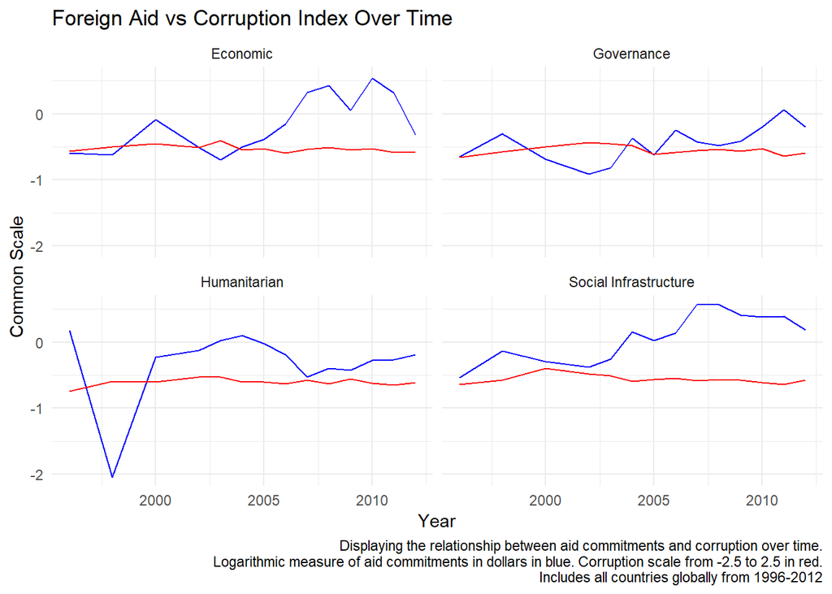

This graph displays aggregated mean corruption index scores and aggregated mean commitments on a common scale for all countries that received over the timescale 1996-2012. The scale is meaningless, only the trend suggests some level of correlation between the changing levels of aid and corruption measures.

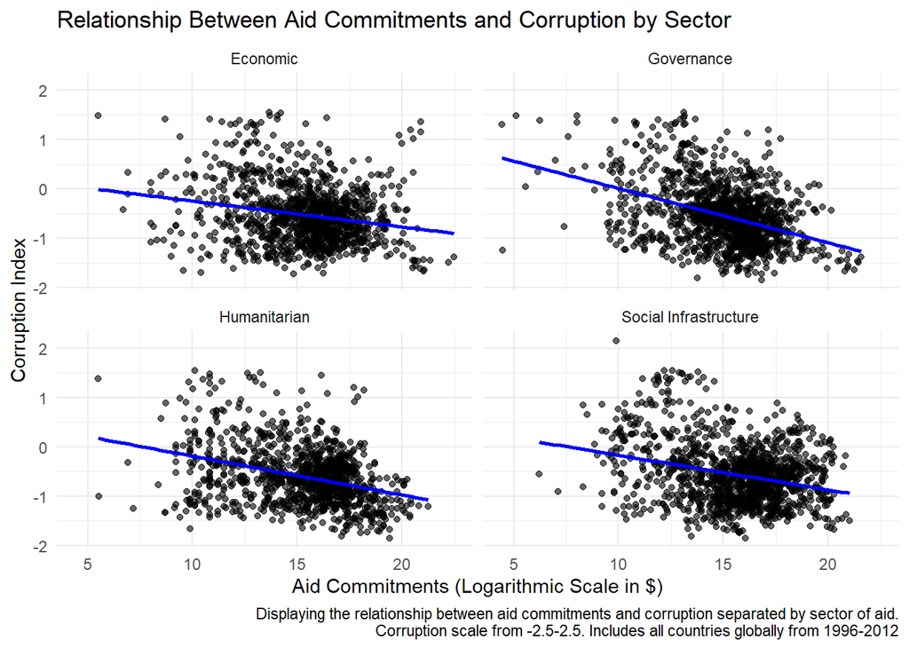

The second graph displays the relationship between aid commitments and corruption measure by sector. Every point is a recipient country, year, and aggregation of projects by sector. No casual relationship is explained, this graph instead displays how the flow of aid by sector is correlated with corruption scores. Contrary to my hypotheses, generally the most aid flows to countries with the lowest corruption score, especially governance and emergency response aid. Institutional capacity is an effective predictor of aid commitments but is also inextricably tied to perceptions of corruption.

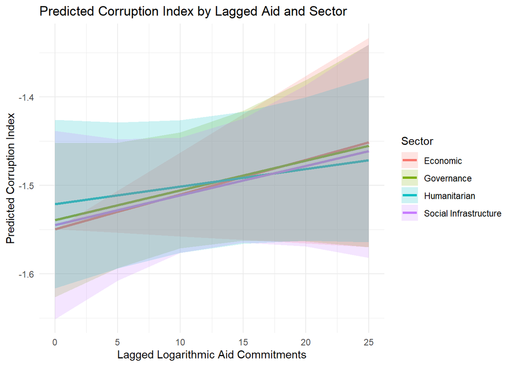

Marginal effect plot of aid lagged by 1 year to predict corruption index to aggregate the significant amount of data from all countries, multiple decades and numerous aid sectors. Contrary to my hypothesis, increases in all sectors of aid appear to lower the incidence of corruption (raise corruption scores) minimally. These results are incredibly variable and should not be interpreted causally.

|  | Bivariate | Multivariate | Fixed Effects |
| --- | --- | --- | --- |
| (Intercept) | 0.473*** (0.056) | 0.146 (0.116) |  |
| aid_lag1 | -0.068*** (0.004) | -0.045*** (0.007) | 0.004 (0.002) |
| sectorGovernance |  | 0.854*** (0.164) | 0.010 (0.044) |
| sectorHumanitarian |  | 0.272+ (0.161) | 0.028 (0.048) |
| sectorSocial Infrastructure |  | 0.240 (0.158) | 0.005 (0.054) |
| aid_lag1 × sectorGovernance |  | -0.059*** (0.011) | -0.001 (0.003) |
| aid_lag1 × sectorHumanitarian |  | -0.023* (0.010) | -0.002 (0.003) |
| aid_lag1 × sectorSocial Infrastructure |  | -0.017+ (0.010) | -0.001 (0.003) |
| Num.Obs. | 4421 | 4421 | 4421 |
| R2 Adj. | 0.075 | 0.083 | 0.921 |
| R2 Within |  |  | 0.001 |
| R2 Within Adj. |  |  | 0.000 |

The main coefficient expresses the change in the corruption index on the -2.5 to 2.5 scale for a 1 unit increase in logarithmic aid or 170% increase in aid. My bivariate regression displays that as aid increases, the corruption score decreases. This relationship can be expected as countries that receive less aid generally have higher corruption scores (lower corruption). The multivariate regression also highlights how at low quantities of aid, countries receiving governance aid have high average corruption scores. The excluded category is economic aid and the multivariate regression displays how all other aid sectors to varying degrees correlate with lower corruption scores with 1 unit increases in logarithmic aid. The magnitudes are quite small, largest being effect of governance aid on corruption index with -0.1 sum on a 5 point scale (-2.5 to 2.5). Additionally, all statistical significant is removed by fixed effects. This is related to the low amount of statistical power with few projects in each year and country; however, more importantly it suggests the majority of the previous relationship between aid and corruption is explained by year and country specific factors. These results highlight no causal relationship between aid and corruption index, regardless of the sector.

#5. Empirical Extension

[figure not shown]

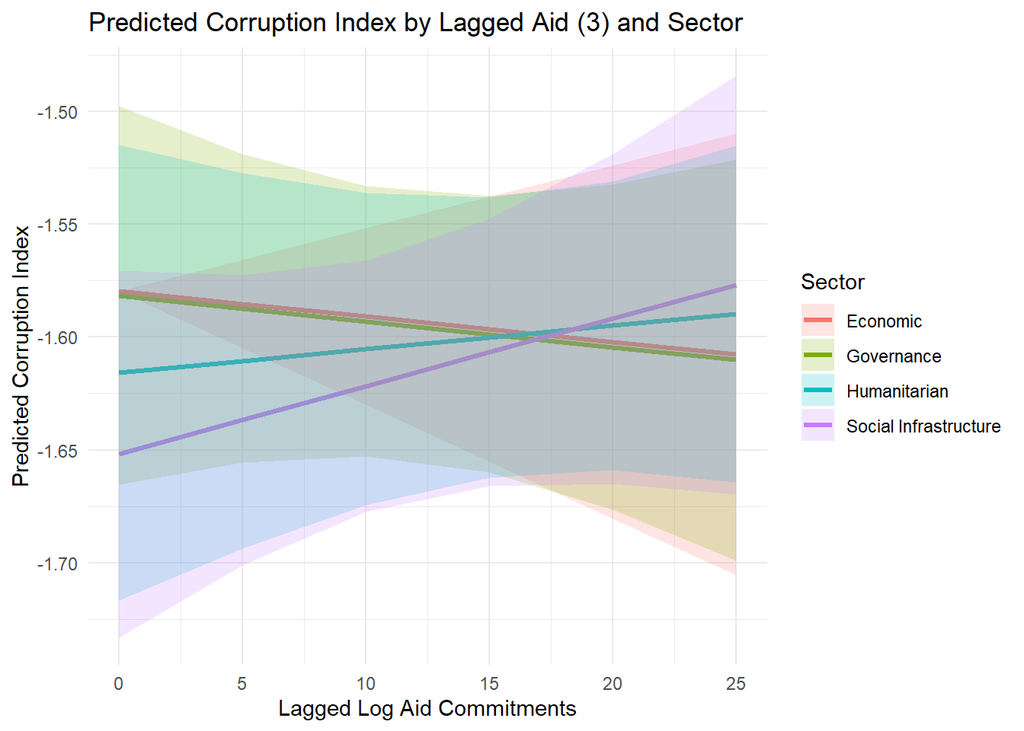

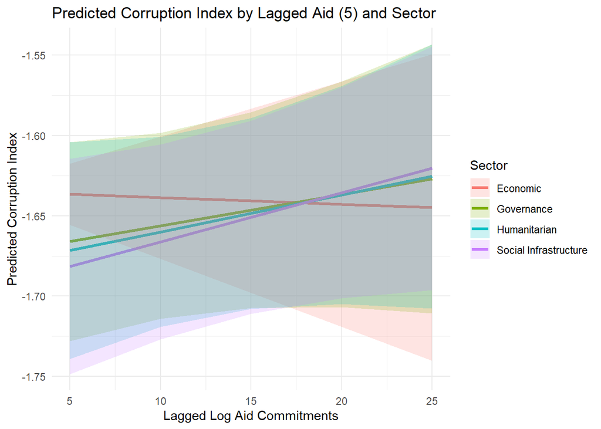

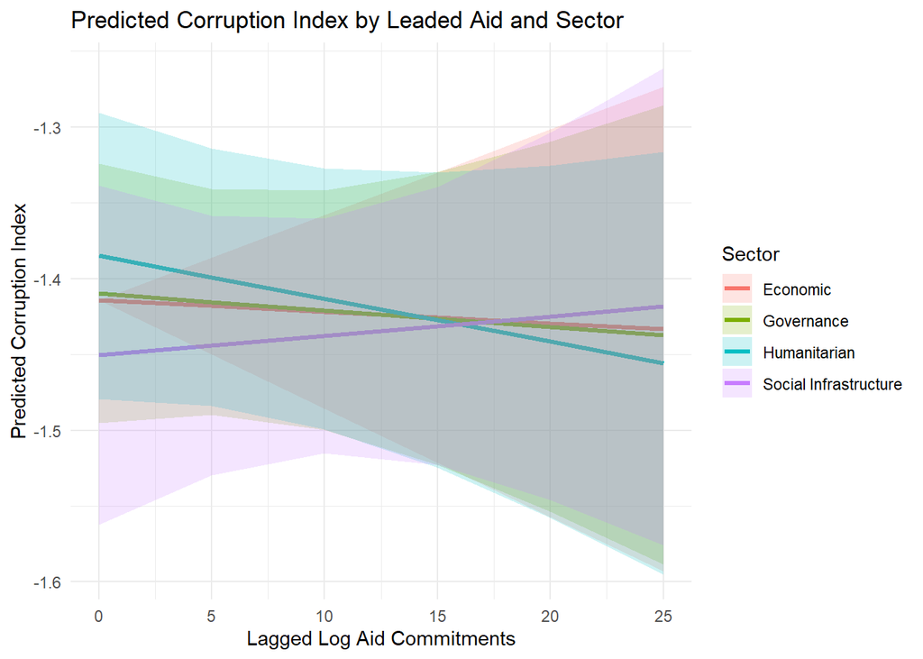

Marginal effect plot of aid lagged by 2, 3, and 5 years respectively to predict corruption index to aggregate the significant amount of data from all countries, multiple decades and numerous aid sectors. These results are similar to the marginal effect plot of aid lagged by 1 year; however, for 3 years both economic and governance aid are associated with decreases in corruption index and for 5 years economic aid is associated with a decrease. This suggests that economic and governance aid are associated with short-term increases in corruption scores that do not persist over time as reliably as humanitarian and social infrastructure aid. These results are incredibly variable and should not be interpreted causally.

|  | Fixed Effects | Fixed Effects 2 | Fixed Effects 3 | Fixed Effects 5 | Fixed Effects -1 |
| --- | --- | --- | --- | --- | --- |
| aid_lag1 | 0.004 (0.002) |  |  |  |  |
| sectorGovernance | 0.010 (0.044) | 0.022 (0.040) | -0.002 (0.042) | -0.041 (0.036) | 0.004 (0.043) |
| sectorHumanitarian | 0.028 (0.048) | 0.008 (0.051) | -0.036 (0.051) | -0.049 (0.041) | 0.029 (0.048) |
| sectorSocial Infrastructure | 0.005 (0.054) | -0.016 (0.047) | -0.072+ (0.041) | -0.062 (0.039) | -0.036 (0.057) |
| aid_lag1 × sectorGovernance | -0.001 (0.003) |  |  |  |  |
| aid_lag1 × sectorHumanitarian | -0.002 (0.003) |  |  |  |  |
| aid_lag1 × sectorSocial Infrastructure | -0.001 (0.003) |  |  |  |  |
| aid_lag2 |  | 0.003 (0.002) |  |  |  |
| aid_lag2 × sectorGovernance |  | -0.001 (0.003) |  |  |  |
| aid_lag2 × sectorHumanitarian |  | -0.001 (0.003) |  |  |  |
| aid_lag2 × sectorSocial Infrastructure |  | 0.001 (0.003) |  |  |  |
| aid_lag3 |  |  | -0.001 (0.002) |  |  |
| aid_lag3 × sectorGovernance |  |  | 0.000 (0.003) |  |  |
| aid_lag3 × sectorHumanitarian |  |  | 0.002 (0.003) |  |  |
| aid_lag3 × sectorSocial Infrastructure |  |  | 0.004+ (0.002) |  |  |
| aid_lag5 |  |  |  | 0.000 (0.002) |  |
| aid_lag5 × sectorGovernance |  |  |  | 0.002 (0.002) |  |
| aid_lag5 × sectorHumanitarian |  |  |  | 0.003 (0.003) |  |
| aid_lag5 × sectorSocial Infrastructure |  |  |  | 0.003 (0.002) |  |
| aid_lead1 |  |  |  |  | -0.001 (0.003) |
| aid_lead1 × sectorGovernance |  |  |  |  | 0.000 (0.003) |
| aid_lead1 × sectorHumanitarian |  |  |  |  | -0.002 (0.003) |
| aid_lead1 × sectorSocial Infrastructure |  |  |  |  | 0.002 (0.003) |
| Num.Obs. | 4421 | 3935 | 3475 | 2629 | 4413 |
| R2 Adj. | 0.921 | 0.930 | 0.936 | 0.954 | 0.911 |
| R2 Within | 0.001 | 0.001 | 0.001 | 0.002 | 0.001 |
| R2 Within Adj. | 0.000 | 0.000 | -0.001 | -0.001 | -0.001 |

#6. Discussion and Policy Implications

Ultimately, local or elite corruption is incredibly difficult to measure accurately. Inherently obscured and protected, any measure of corruption relies on significant assumptions. Effective measures to observe aid leakage and state corruption have been designed; however, future research should center on perceptions of local and state corruption as effective benchmarks and as governance tools in and of themselves. World Bank Group research has shown that citizen perceptions of state trust and legitimacy directly effect state capacity and developmental outcomes. To better define causality, geocoded data should be utilized to protect against exogenous factors that affect citizen perceptions irrespective of foreign aid and to isolate a causal pathway by which aid effects perceptions of corruption.

## References

Anderson, Jorgen J. 2022. “Elite Capture of Foreign Aid: Evidence from Offshore Bank Accounts.” *Journal of Political Economy* 130 (2): 187–206. https://doi.org/10.1086/717455.

Baldwin, Kate, and Matthew S. Winters. 2023. “Foreign Aid and Political Support: How Politicians’ Aid Oversight Capacity and Voter Information Condition Credit-Giving.” *World Politics* 75 (1): 1–42. https://doi.org/10.1353/wp.2023.0004.

Bold, Tessa, Mwangi Kimenyi, Germano Mwabu, Alice Ng’ang’a, and Justin Sandefur. 2018. “Experimental Evidence on Scaling up Education Reforms in Kenya.” *Journal of Public Economics* 168: 1–20. https://doi.org/https://doi.org/10.1016/j.jpubeco.2018.08.007.

Briggs, Ryan C. 2017. “Does Foreign Aid Target the Poorest?” *International Organization* 71 (1): 187–206. https://doi.org/10.1017/S0020818316000345.

Cruz, Cesi, and Christina J. Schneider. 2017. “Foreign Aid and Undeserved Credit Claiming.” *American Journal of Political Science* 61 (2): 396–408. https://doi.org/https://doi.org/10.1111/ajps.12285.

Dietrich, Simone, and Matthew S. Winters. 2023. “Chapter: Foreign Aid and Quality of Government.” *Forthcoming*, 1–37. https://drive.google.com/file/d/1v9fSxgocPY9pvYKuRT77KjeHFg4Q4b1q/view.

Evans, David K. 2021. “Building State Capacity: What Is the Impact of Development Projects?” *World Bank Group* 71 (1): 187–206. https://doi.org/10.1017/S0020818316000345.

Ingram, G. 2024. “What Is u.s. Foreign Assistance.” *Brookings*. https://www.brookings.edu/articles/what-is-us-foreign-assistance/.

Kenny, Charles. 2024. “Is 20.” *Center for Global Development*, March. https://www.cgdev.org/blog/20-aid-really-lost-corruption-zombie-statistics-and-their-sources.

Okada, Keisuke, and Sovannroeun Samreth. 2012. “The Effect of Foreign Aid on Corruption: A Quantile Regression Approach.” *Economics Letters* 115 (2): 240–43. https://doi.org/https://doi.org/10.1016/j.econlet.2011.12.051.

Reinikka, Ritva, and Jakob Svensson. 2004. “Local Capture: Evidence from a Central Government Transfer Program in Uganda.” *The Quarterly Journal of Economics* 119 (2): 679–705. https://doi.org/10.1162/0033553041382120.

Tierney, Daniel L. Nielson, Michael J., and Robert L. Hicks. 2011. “More Dollars Than Sense: Refining Our Knowledge of Development Finance Using AidData.” *World Development* 39 (11): 1891–1906. http://aiddata.org/datasets.